# Measles outbreak, Bangladesh 2026: descriptive epidemiology

Published

October 5, 2026

```r
library(here)
library(dplyr)
library(tidyr)
library(lubridate)
library(ggplot2)
library(ggridges)
library(plotly)
library(sf)
library(slider)
library(knitr)

# visualise-data palette
col_primary <- "#1a1a1a"
col_highlight <- "#c0392b"
col_reference <- "#7f7f7f"
# Okabe-Ito, one colour per division
col_divisions <- c("#E69F00", "#56B4E9", "#009E73", "#F0E442",
                   "#0072B2", "#D55E00", "#CC79A7", "#999999")
theme_set(
  theme_bw(base_size = 11) +
    theme(panel.grid.minor = element_blank(), legend.position = "bottom")
)
sf_use_s2(FALSE)

# Utility functions
# MMWR epidemiological weeks, Sunday to Saturday, labelled by start date
week_start_of <- function(date) floor_date(date, "week", week_start = 7)
week_label <- function(week) {
  paste0("week ", epiweek(week), " (", fmt_date(week), " to ",
         fmt_date(week + 6), ")")
}
# Sum daily counts by complete epiweek, grouped by the columns in ...
weekly <- function(d, ...) {
  d |>
    mutate(week = week_start_of(date)) |>
    filter(between(week, first_week, last_week)) |>
    group_by(..., week) |>
    summarise(across(c(suspected, confirmed, total, serum_sent), sum),
              .groups = "drop")
}
fmt <- function(x) format(round(x), big.mark = ",")
fmt_date <- function(d, year = FALSE) {
  paste(day(d), format(d, if (year) "%B %Y" else "%B"))
}
```

```r
# DGHS dashboard series by report date
cases <- read.csv(here("data", "dghs-cases.csv"), na.strings = c("", "NA")) |>
  mutate(date = ymd(date))
cutoff <- max(cases$date)
first_report <- ymd("2026-03-15")
first_daily <- ymd("2026-04-08")
# First and last complete epiweeks of daily data
first_week <- week_start_of(first_daily - 1) + 7
last_week <- week_start_of(cutoff + 1) - 7

# DGHS district spellings that differ from the OCHA boundaries
district_recode <- c(
  Jhalakathi = "Jhalokati",
  Netrokona = "Netrakona",
  Chapainawabganj = "Chapainababganj"
)
cases <- cases |>
  mutate(district = recode(district, !!!district_recode))

# Boundaries and population (2022 census projection)
adm1 <- st_read(here("data", "covariates", "bgd_adm1.geojson"), quiet = TRUE)
adm2 <- st_read(here("data", "covariates", "bgd_adm2.geojson"), quiet = TRUE)
lookup <- read.csv(here("data", "covariates", "admin_lookup.csv"))

# Divisions west to east by centroid, and districts the same way within each
centroid_lon <- function(g) {
  suppressWarnings(st_coordinates(st_centroid(g))[, 1])
}
division_order <- adm1 |>
  mutate(lon = centroid_lon(geometry)) |>
  arrange(lon) |>
  pull(adm1_name)
district_order <- adm2 |>
  mutate(
    lon = centroid_lon(geometry),
    division = factor(adm1_name, levels = division_order)
  ) |>
  arrange(division, lon) |>
  pull(adm2_name)

pop1 <- read.csv(here("data", "covariates", "population_adm1.csv")) |>
  select(adm1_pcode, pop = t_tl, pop_u5 = t_00_04) |>
  left_join(distinct(lookup, adm1_pcode, division = adm1_name),
            by = "adm1_pcode")
pop2 <- read.csv(here("data", "covariates", "population_adm2.csv")) |>
  select(adm2_pcode, pop = t_tl, pop_u5 = t_00_04) |>
  left_join(select(lookup, adm2_pcode, district = adm2_name,
                   division = adm1_name),
            by = "adm2_pcode")
stopifnot(
  setequal(pop1$division, unique(na.omit(cases$division))),
  setequal(pop2$district, unique(na.omit(cases$district)))
)

# Wide daily series: one row per date and place, one column per measure.
# Total = suspected + confirmed, treating the two as separate counts
widen <- function(d) {
  d |>
    select(-fetched_at, -flag) |>
    pivot_wider(names_from = measure, values_from = value) |>
    mutate(total = suspected + confirmed,
           total_deaths = suspected_deaths + confirmed_deaths)
}
nat_daily <- cases |>
  filter(level == "national") |>
  widen()
div_daily <- cases |>
  filter(level == "division") |>
  widen() |>
  mutate(division = factor(division, levels = division_order))
dist_daily <- cases |>
  filter(level == "district") |>
  widen() |>
  mutate(district = factor(district, levels = district_order),
         division = factor(division, levels = division_order))
# 15 March to 7 April, loaded onto 7 April as one total
lump <- nat_daily |> filter(date == first_daily - 1)
lump_days <- as.numeric(first_daily - first_report)

# Events marked on time series
events <- read.csv(here("assets", "events.csv")) |>
  mutate(date = ymd(date))
events_marked <- events |>
  filter(!grepl("backfill", event))

# WHO provisional monthly measles and rubella data
who <- read.csv(here("data", "who-monthly.csv")) |>
  mutate(month = make_date(year, month, 1)) |>
  filter(year >= 2023)
```

**Note**

- Data to 3 October 2026, from the DGHS measles monitoring platform (measles.dghs.gov.bd). Many thanks to DGHS for making these data public.
- A case is a hospital admission with suspected or confirmed measles. In this analysis, total cases = suspected + confirmed.

**Data and definitions**

## Data reporting process

- Facilities report measles admissions daily, collated by district civil surgeon offices and submitted as daily counts to the DGHS platform.
- Daily surveillance reporting start on 8 April. Cases from 15 March to 7 April were accumulated onto 7 April as one total (12,392 cases: 10,878 suspected, 1,514 confirmed).
- Dates are report dates, and place is the district of the reporting facility.
- Weeks are MMWR epidemiological weeks, Sunday to Saturday. Weekly figures show complete weeks only.
- Population is the 2022 census projection.

### Source data variables

```r
tibble::tribble(
  ~measure, ~dashboard_label, ~notes,
  "suspected", "suspected24h", "Hospital admissions with suspected measles; whether confirmed are included is not stated",
  "confirmed", "confirmed24h", "Laboratory method not stated",
  "total", "(derived)", "suspected + confirmed; assumes the two are separate",
  "suspected_deaths", "suspectedDeath24h", "Whether confirmed deaths are included, and place of death, not stated",
  "confirmed_deaths", "confirmedDeath24h", "As above",
  "total_deaths", "(derived)", "suspected_deaths + confirmed_deaths; assumes the two are separate",
  "admitted", "admitted24h", "Relation to suspected not stated",
  "discharged", "discharged24h", "\"Recovered\" in the dashboard's Excel export",
  "serum_sent", "serumSent24h", "Serum samples sent to the laboratory; not in the Excel export"
) |>
  kable(col.names = c("Measure", "Dashboard label", "Notes"))
```

Table 1: DGHS dashboard indicators, reported as 24-hour counts by report date

| Measure | Dashboard label | Notes |
| --- | --- | --- |
| suspected | suspected24h | Hospital admissions with suspected measles; whether confirmed are included is not stated |
| confirmed | confirmed24h | Laboratory method not stated |
| total | (derived) | suspected + confirmed; assumes the two are separate |
| suspected_deaths | suspectedDeath24h | Whether confirmed deaths are included, and place of death, not stated |
| confirmed_deaths | confirmedDeath24h | As above |
| total_deaths | (derived) | suspected_deaths + confirmed_deaths; assumes the two are separate |
| admitted | admitted24h | Relation to suspected not stated |
| discharged | discharged24h | “Recovered” in the dashboard’s Excel export |
| serum_sent | serumSent24h | Serum samples sent to the laboratory; not in the Excel export |

### WHO standard measles case definitions

```r
read.csv(here("assets", "case-definitions.csv")) |>
  select(classification, definition) |>
  kable(col.names = c("Classification", "Definition"))
```

Table 2: WHO measles surveillance case definitions, used in WHO monthly data (verbatim)

| Classification | Definition |
| --- | --- |
| Suspected | A suspected case is one in which a patient with fever and maculopapular (non-vesicular) rash, or in whom a health-care worker suspects measles. |
| Laboratory-confirmed | Laboratory-confirmed measles: A suspected case of measles that has been confirmed positive by testing in a proficient laboratory, and vaccine-associated illness has been ruled out (see the section bel… |
| Epidemiologically linked | Epidemiologically linked measles: A suspected case of measles that has not been confirmed by a laboratory, but was geographically and temporally related with dates of rash onset occurring 7–23 days ap… |
| Clinically compatible | Clinically compatible measles: A suspected case with fever and maculopapular (non-vesicular) rash and at least one of cough, coryza or conjunctivitis, but no adequate clinical specimen was taken and t… |
| Non-measles discarded | Non-measles discarded case: A suspected case that has been investigated and discarded as a non-measles (and non-rubella) when any of the following are true: » negative laboratory testing in a proficie… |
| Total measles cases (counting rule) | Note about counting measles cases: total measles cases are usually the sum of laboratory-confirmed cases, epidemiologically linked cases and clinically compatible cases. |

# Situation update

```r
cum <- nat_daily |>
  summarise(across(c(suspected, confirmed, total, suspected_deaths,
                     confirmed_deaths, total_deaths), sum))
nat_weekly <- weekly(nat_daily) |>
  mutate(per_100k = 1e5 * total / sum(pop1$pop))
this_week <- nat_weekly |> filter(week == last_week)
prev_week <- nat_weekly |> filter(week == last_week - 7)
change_pct <- 100 * (this_week$total / prev_week$total - 1)
div_last <- weekly(div_daily, division) |>
  filter(week == last_week) |>
  left_join(pop1, by = "division") |>
  mutate(per_100k = 1e5 * total / pop) |>
  arrange(desc(per_100k))
dist_last <- weekly(dist_daily, district) |>
  filter(week == last_week)
```

- Cumulative, 15 March to 3 October: 216,866 cases (195,200 suspected, 21,666 confirmed) and 1,122 deaths (1,020 suspected, 102 confirmed).
- Latest complete week 39 (27 September to 3 October): 8,954 cases, +2% on the week before, 5.4 per 100,000 population (Figure 1).
- 63 of 64 districts reported a case in the latest week. Highest division incidence: Barishal, 11.2 per 100,000.

## Epidemic curve

The outbreak was alerted to public health surveillance on 15 March, with daily counts reported from 8 April. The outbreak likely began earlier.

```r
type_levels <- c("Suspected", "Confirmed")
type_colours <- c(Suspected = col_reference, Confirmed = col_highlight)
nat_weekly_long <- nat_weekly |>
  mutate(text = paste0(week_label(week), ": ", fmt(total), " cases (",
                       fmt(suspected), " suspected, ", fmt(confirmed),
                       " confirmed)")) |>
  pivot_longer(c(suspected, confirmed), names_to = "type",
               values_to = "cases") |>
  mutate(type = factor(tools::toTitleCase(type), levels = type_levels))

# Lumped total as a weekly average, confirmed below suspected
lump_rate <- 7 / lump_days
lump_rect <- tibble(
  type = factor(type_levels, levels = type_levels),
  ymin = c(lump$confirmed, 0) * lump_rate,
  ymax = c(lump$total, lump$confirmed) * lump_rate,
  text = paste0("15 March to 7 April, reported as one total: ",
                fmt(lump$total), " cases (", fmt(lump$suspected),
                " suspected, ", fmt(lump$confirmed), " confirmed)")
)

p <- ggplot() +
  geom_rect(data = lump_rect,
            aes(xmin = first_report, xmax = first_daily, ymin = ymin,
                ymax = ymax, fill = type, text = text),
            alpha = 0.35, colour = col_primary, linetype = "dashed",
            linewidth = 0.3, show.legend = FALSE) +
  geom_col(data = nat_weekly_long,
           aes(week + 3.5, cases, fill = type, text = text), width = 7) +
  geom_vline(data = filter(events_marked, date >= first_report),
             aes(xintercept = date), colour = col_primary,
             linetype = "dotted") +
  annotate("text", x = first_report, y = max(lump_rect$ymax),
           label = "Reported as\none total", hjust = 0, vjust = -0.3,
           size = 3, colour = col_reference) +
  scale_fill_manual(values = type_colours) +
  scale_x_date(date_labels = "%b") +
  labs(x = "Epiweek", y = "Cases per week", fill = NULL)
ggplotly(p, tooltip = "text")
```

[interactive chart not shown]

Figure 1: Measles hospital admissions per epidemiological week, confirmed and suspected, Bangladesh, 15 March 2026 to the latest complete week. Shaded block: 15 March to 7 April, reported as one total and shown at its weekly average; 8 to 11 April, a partial week, is not shown. Dotted lines: campaign start in high-risk upazilas (5 April); nationwide campaign (20 April); camp campaign and platform launch (26 April). Source: DGHS measles monitoring platform, report date.

Epidemiological intervals (i.e. the incubation period, the time from symptom onset to medical admission, and the time from admission to data report): see Appendix A.

**Last 7 days’ data extract**

```r
nat_daily |>
  select(date, suspected, confirmed, total, suspected_deaths,
         confirmed_deaths, admitted, discharged, serum_sent) |>
  tail(7) |>
  kable(caption = "Daily DGHS measles dashboard data, national",
        format.args = list(big.mark = ","))
```

Daily DGHS measles dashboard data, national

| date | suspected | confirmed | total | suspected_deaths | confirmed_deaths | admitted | discharged | serum_sent |
| --- | --- | --- | --- | --- | --- | --- | --- | --- |
| 2026-09-27 | 1,228 | 113 | 1,341 | 9 | 0 | 1,155 | 943 | 407 |
| 2026-09-28 | 1,214 | 96 | 1,310 | 3 | 0 | 1,159 | 1,186 | 431 |
| 2026-09-29 | 1,255 | 84 | 1,339 | 5 | 0 | 1,186 | 1,093 | 482 |
| 2026-09-30 | 1,221 | 128 | 1,349 | 4 | 0 | 1,145 | 1,075 | 472 |
| 2026-10-01 | 1,132 | 82 | 1,214 | 2 | 0 | 1,077 | 1,100 | 367 |
| 2026-10-02 | 1,221 | 21 | 1,242 | 3 | 1 | 1,144 | 1,049 | 275 |
| 2026-10-03 | 1,116 | 43 | 1,159 | 8 | 0 | 1,006 | 824 | 289 |

# Spatial spread

```r
district_cum <- dist_daily |>
  group_by(district) |>
  summarise(total = sum(total), .groups = "drop") |>
  left_join(pop2, by = "district") |>
  mutate(per_100k = 1e5 * total / pop)
stopifnot(nrow(district_cum) == 64, !anyNA(district_cum$pop))

map_districts <- adm2 |>
  left_join(district_cum, by = c("adm2_name" = "district"))
breaks_100k <- c(0, 25, 50, 100, 200, 400, 800)
stopifnot(!anyNA(map_districts$per_100k),
          max(map_districts$per_100k) <= max(breaks_100k))
```

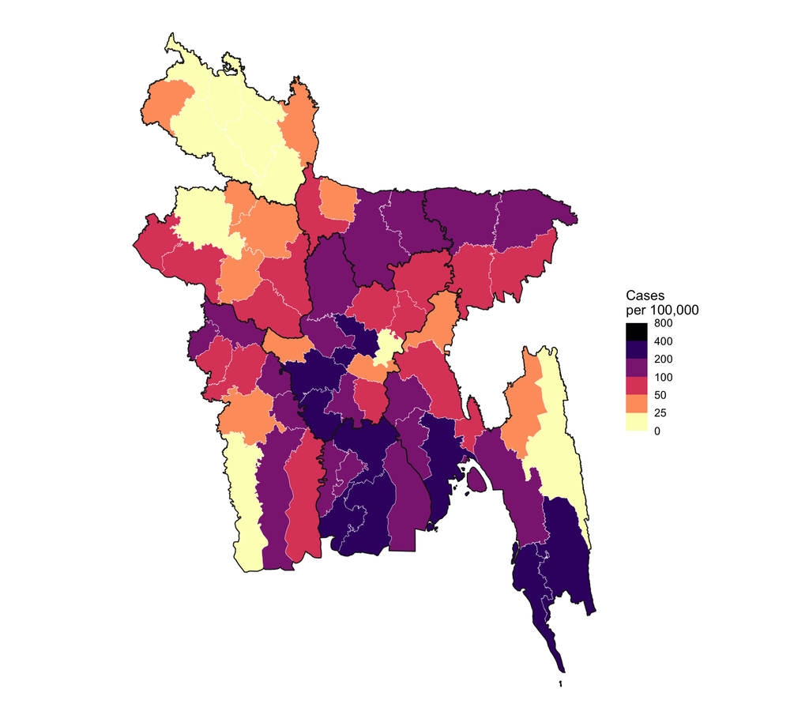

Figure 2: Cumulative measles cases (suspected + confirmed) per 100,000 population, by district of reporting facility, 15 March 2026 to cutoff. Sources: DGHS measles monitoring platform; 2022 census projection.

```r
ggplot() +
  geom_sf(data = map_districts, aes(fill = per_100k), colour = "white",
          linewidth = 0.1) +
  geom_sf(data = adm1, fill = NA, colour = col_primary, linewidth = 0.4) +
  scale_fill_viridis_b(breaks = breaks_100k, limits = range(breaks_100k),
                       option = "magma", direction = -1,
                       show.limits = TRUE) +
  labs(fill = "Cases\nper 100,000") +
  theme_void() +
  theme(legend.position = "right")
```

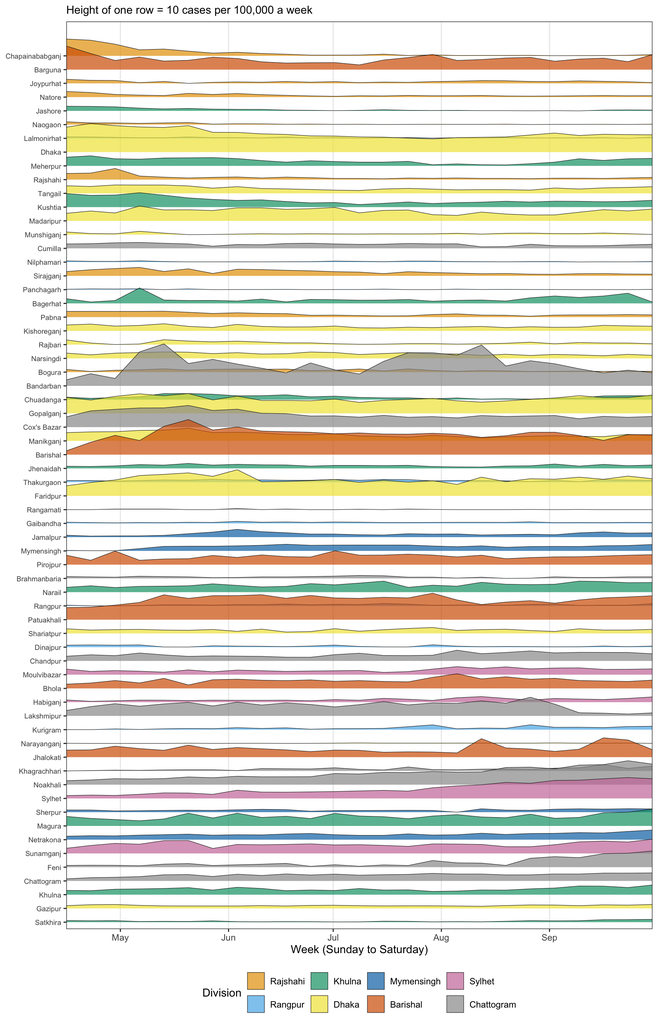

Figure 3: Weekly measles cases (suspected + confirmed) per 100,000 population, by district of reporting facility, from 12 April 2026 to the latest complete week. Districts ordered by week of peak incidence. Sources: DGHS measles monitoring platform, report date; 2022 census projection.

```r
# Incidence 15 March to 7 April, the earliest district data
pre_platform <- dist_daily |>
  filter(date == first_daily - 1) |>
  left_join(select(pop2, district, pop), by = "district") |>
  transmute(district = as.character(district),
            pre_100k = 1e5 * total / pop)
dist_weekly <- weekly(dist_daily, division, district) |>
  left_join(select(pop2, district, pop), by = "district") |>
  mutate(per_100k = 1e5 * total / pop)
# Factor levels run bottom to top: latest peak first, so the earliest
# peak is the top row
ridge_order <- dist_weekly |>
  group_by(district = as.character(district)) |>
  summarise(peak_week = week[which.max(per_100k)], .groups = "drop") |>
  left_join(pre_platform, by = "district") |>
  arrange(desc(peak_week), pre_100k) |>
  pull(district)
# One row of height on the y axis, in cases per 100,000 a week
row_100k <- signif(max(dist_weekly$per_100k) / 3, 1)

dist_weekly |>
  ggplot(aes(week + 3.5, factor(district, levels = ridge_order),
             height = per_100k, fill = division)) +
  geom_ridgeline(scale = 1 / row_100k, alpha = 0.7, colour = col_primary,
                 linewidth = 0.2) +
  scale_fill_manual(values = col_divisions) +
  scale_x_date(date_labels = "%b", expand = c(0, 0)) +
  # Room above the top ridges
  scale_y_discrete(expand = expansion(add = c(0.5, 2.5))) +
  labs(x = "Week (Sunday to Saturday)", y = NULL, fill = "Division",
       subtitle = paste("Height of one row =", row_100k,
                        "cases per 100,000 a week")) +
  theme(axis.text.y = element_text(size = 7),
        panel.grid.major.y = element_blank())
```

## Cox’s Bazar and refugee camps

Refugee camps report separately from the DGHS platform, where camp health facilities report syndromic surveillance directly to the Rohingya Response early warning system (EWARS).

```r
# EWARS weekly suspected measles/rubella in the camps, digitised from the
# W36 2026 bulletin chart; confirmed as a series (data/camps-review.csv)
ewars <- read.csv(here("data", "camps-ewars-weekly.csv")) |>
  filter(confirmed_by != "") |>
  transmute(week = ymd(week_start), ewars = value)
# DGHS admissions reported by facilities in Cox's Bazar district
coxs_weekly <- dist_daily |>
  filter(district == "Cox's Bazar") |>
  weekly() |>
  select(week, dghs = total)
camps_weekly <- full_join(ewars, coxs_weekly, by = "week") |>
  arrange(week)

# Camp case and death figures from situation reports and bulletins,
# confirmed against the source page
camps_figures <- read.csv(here("data", "camps-measles.csv"),
                          na.strings = "") |>
  filter(!is.na(confirmed_by),
         indicator %in% c("camp_suspected_cases", "camp_confirmed_cases",
                          "camp_epilinked_cases", "camp_total_cases",
                          "camp_deaths", "camp_admissions")) |>
  mutate(date = ymd(coalesce(as_of_date, published_date)))
```

```r
p <- camps_weekly |>
  mutate(text = paste0(week_label(week), ": ",
                       if_else(is.na(ewars), "", paste0(fmt(ewars), " camps")),
                       if_else(is.na(dghs), "",
                               paste0("; ", fmt(dghs), " Cox's Bazar (DGHS)")))) |>
  ggplot(aes(week + 3.5)) +
  geom_col(aes(y = ewars, fill = "Camps (EWARS)", text = text), width = 7,
           na.rm = TRUE) +
  geom_line(aes(y = dghs, colour = "Cox's Bazar district (DGHS)"),
            na.rm = TRUE) +
  geom_point(aes(y = dghs, colour = "Cox's Bazar district (DGHS)",
                 text = text), size = 1, na.rm = TRUE) +
  geom_vline(data = filter(events, scope == "camps"),
             aes(xintercept = date), colour = col_primary,
             linetype = "dotted") +
  scale_fill_manual(values = c("Camps (EWARS)" = col_reference)) +
  scale_colour_manual(values = c("Cox's Bazar district (DGHS)" =
                                   col_highlight)) +
  scale_x_date(date_labels = "%b %Y") +
  labs(x = "Week (Sunday to Saturday)", y = "Cases per week",
       fill = NULL, colour = NULL)
ggplotly(p, tooltip = "text")
```

[interactive chart not shown]

Figure 4: Suspected measles cases per epidemiological week in the refugee camps (bars), and measles admissions (suspected + confirmed) reported by facilities in Cox’s Bazar district (line), 22 December 2024 to 12 September 2026. Dotted line: camp MR campaign (26 April). Sources: Rohingya Response EWARS bulletin W36 2026 (Figure 4, digitised); DGHS measles monitoring platform, report date.

**Camp case and death figures in situation reports**

```r
camps_figures |>
  arrange(indicator, date) |>
  transmute(
    measure = sub("^camp_", "", indicator) |> gsub(pattern = "_", replacement = " "),
    value = fmt(value),
    date = if_else(is.na(date), "", format(date, "%e %b")),
    geography, period = coalesce(period_text, period, ""),
    source = doc_id, note = coalesce(gsub("\n", " ", review_note), "")
  ) |>
  kable(col.names = c("Measure", "Value", "As of or published", "Geography",
                      "Period", "Document", "Reviewer note"))
```

Table 3: Indicators of measles cases and deaths in Cox’s Bazar refugee camps. Note that geography, period and denominator are not reported consistently and differ between documents, so are presented as stated. Sources: Health Sector Cox’s Bazar bulletins; UN RCO, UNICEF and WHO SEARO reports.

| Measure | Value | As of or published | Geography | Period | Document | Reviewer note |
| --- | --- | --- | --- | --- | --- | --- |
| admissions | 43 |  | camps | EW 18 | Health-Sector-Coxs-Bazar-monthly-Bulletin-June-2026 | Epidemiological Week (EW) |
| admissions | 8 |  | camps | EW 25 | Health-Sector-Coxs-Bazar-monthly-Bulletin-June-2026 |  |
| admissions | 108 |  | not stated | Epiweek 16–21 | Health-Sector-Coxs-Bazar-monthly-Bulletin-May-2026 | Check the other key facts in this are somewhere in our data: In response to a camp-wide measles outbreak, MSF opened a 20-bed measles isolation unit in Camp 15. From Epiweek 16–21, 108 patients were a… |
| confirmed cases | 8 | 8 Apr | camps | cumulative | bangladesh-humanitarian-situation-report-no-1measles-outbreak-8-april-2026 |  |
| confirmed cases | 7 | 8 Apr | Cox’s Bazar camps | cumulative | bangladesh-humanitarian-situation-report-no-1measles-outbreak-8-april-2026 | As of 30 March 2026 |
| confirmed cases | 1 | 8 Apr | Bhasan Char | cumulative | bangladesh-humanitarian-situation-report-no-1measles-outbreak-8-april-2026 |  |
| confirmed cases | 8 | 16 Apr | camps | cumulative | 314522 |  |
| confirmed cases | 7 | 16 Apr | Cox’s Bazar camps | cumulative | 314522 |  |
| confirmed cases | 1 | 16 Apr | Bhasan Char | cumulative | 314522 |  |
| confirmed cases | 8 | 22 Apr | Rohingya refugee camps; camps | as of 22 April | 314356 |  |
| confirmed cases | 52 | 30 Apr | Rohingya camps; Teknaf; camps | In April 2026 | Health-Sector-Coxs-Bazar-monthly-Bulletin-April-2026 | note 52 confirmed positive of the 163 suspected |
| confirmed cases | 40 | 7 May | Rohingya refugee camps; Cox’s Bazar; camps |  | 315718 |  |
| confirmed cases | 60 | 21 May | Cox’s Bazar; Bhasan Char; camps |  | 315984 | cumulative: “60… to date”. also applies to 5 deaths and 595 suspected in this report. |
| confirmed cases | 105 | 25 Jun | camps including Bhasan Char | cumulative | 319256 |  |
| confirmed cases | 105 | 25 Jun | Rohingya refugee camps; Cox’s Bazar; Bhasan Char; camps | As of 25 June 2026; June 2026 | 2026_13_searo_epi_bulletin |  |
| confirmed cases | 4 | 30 Jun | Teknaf | In June 2026 | Health-Sector-Coxs-Bazar-monthly-Bulletin-June-2026 |  |
| confirmed cases | 129 | 2 Jul | not stated | as of 2 July 2026; July 2026 | Health-Sector-Coxs-Bazar-monthly-Bulletin-June-2026 | total as of 2 july |
| confirmed cases | 40 |  | Bhasan Char; Teknaf; camps; Camps |  | Health-Sector-Coxs-Bazar-monthly-Bulletin-April-2026 | 40/134; note: “WHO continues to investigate every case, and active case search has been enhanced for timely identification and isolation of all suspected cases” |
| confirmed cases | 33 |  | Ukhia | cumulative | Health-Sector-Coxs-Bazar-monthly-Bulletin-April-2026 |  |
| confirmed cases | 7 |  | Teknaf | cumulative | Health-Sector-Coxs-Bazar-monthly-Bulletin-April-2026 |  |
| confirmed cases | 1 |  | Bhasan Char | cumulative | Health-Sector-Coxs-Bazar-monthly-Bulletin-April-2026 |  |
| confirmed cases | 284 |  | not stated |  | Health-Sector-Coxs-Bazar-monthly-Bulletin-July-2026 |  |
| confirmed cases | 4 |  | camps |  | Health-Sector-Coxs-Bazar-monthly-Bulletin-June-2026 | 4 lab confirmed in June |
| deaths | 2 | 29 Apr | camps; Dhaka | As of 29 April 2026; April 2026 | Health-Sector-Coxs-Bazar-monthly-Bulletin-April-2026 | “as of” |
| deaths | 5 | 21 May | Cox’s Bazar; Bhasan Char; camps |  | 315984 |  |
| deaths | 5 | 25 Jun | camps including Bhasan Char | cumulative | 319256 |  |
| deaths | 5 | 25 Jun | Rohingya refugee camps; Cox’s Bazar; Bhasan Char; camps | As of 25 June 2026; June 2026 | 2026_13_searo_epi_bulletin | “reported to date” |
| deaths | 5 | 2 Jul | not stated | as of 2 July 2026; July 2026 | Health-Sector-Coxs-Bazar-monthly-Bulletin-June-2026 |  |
| deaths | 10 |  | not stated |  | Health-Sector-Coxs-Bazar-monthly-Bulletin-July-2026 | suspected |
| epilinked cases | 138 | 30 Jun | Teknaf | In June 2026 | Health-Sector-Coxs-Bazar-monthly-Bulletin-June-2026 |  |
| epilinked cases | 578 | 2 Jul | not stated | as of 2 July 2026; July 2026 | Health-Sector-Coxs-Bazar-monthly-Bulletin-June-2026 |  |
| epilinked cases | 970 |  | not stated |  | Health-Sector-Coxs-Bazar-monthly-Bulletin-July-2026 |  |
| suspected cases | 70 | 8 Apr | Cox’s Bazar camps | cumulative | bangladesh-humanitarian-situation-report-no-1measles-outbreak-8-april-2026 |  |
| suspected cases | 6 | 8 Apr | Bhasan Char | cumulative | bangladesh-humanitarian-situation-report-no-1measles-outbreak-8-april-2026 |  |
| suspected cases | 214 | 16 Apr | camps | cumulative | 314522 |  |
| suspected cases | 206 | 16 Apr | Cox’s Bazar camps | cumulative | 314522 |  |
| suspected cases | 8 | 16 Apr | Bhasan Char | cumulative | 314522 |  |
| suspected cases | 331 | 22 Apr | Rohingya refugee camps; camps | as of 22 April | 314356 |  |
| suspected cases | 461 | 29 Apr | camps; Dhaka | As of 29 April 2026; April 2026 | Health-Sector-Coxs-Bazar-monthly-Bulletin-April-2026 |  |
| suspected cases | 163 | 30 Apr | Rohingya camps; Teknaf; camps | In April 2026 | Health-Sector-Coxs-Bazar-monthly-Bulletin-April-2026 | “in april” period |
| suspected cases | 461 | 7 May | Rohingya refugee camps; Cox’s Bazar; camps |  | 315718 |  |
| suspected cases | 595 | 21 May | Cox’s Bazar; Bhasan Char; camps |  | 315984 | cumulative |
| suspected cases | 50 | 31 May | camps | In May 2026 | Health-Sector-Coxs-Bazar-monthly-Bulletin-May-2026 | 50 suspected, reported, *AND lab confirmed* in May 2026 |
| suspected cases | 50 | 31 May | Teknaf | In May 2026 | Health-Sector-Coxs-Bazar-monthly-Bulletin-May-2026 | note 50 were lab positive (ie 100% test positivity) |
| suspected cases | 865 | 25 Jun | camps including Bhasan Char | cumulative | 319256 |  |
| suspected cases | 865 | 25 Jun | Rohingya refugee camps; Cox’s Bazar; Bhasan Char; camps | As of 25 June 2026; June 2026 | 2026_13_searo_epi_bulletin |  |
| suspected cases | 142 | 30 Jun | Teknaf | In June 2026 | Health-Sector-Coxs-Bazar-monthly-Bulletin-June-2026 |  |
| suspected cases | 1,824 |  | not stated |  | Health-Sector-Coxs-Bazar-monthly-Bulletin-July-2026 | in 2026 cumulative up to july |
| total cases | 1,254 |  | not stated |  | Health-Sector-Coxs-Bazar-monthly-Bulletin-July-2026 |  |

# Lab testing

The DGHS platform records volume of serum samples. This isn’t proper test positivity, as samples sent aren’t directly linked to confirmed cases.

```r
serum_start <- ymd("2026-05-01")
sum_testing <- function(d) {
  d |>
    filter(date >= serum_start) |>
    summarise(across(c(suspected, confirmed, total, serum_sent), sum))
}
bind_rows(
  div_daily |>
    group_by(place = as.character(division)) |>
    sum_testing(),
  nat_daily |>
    sum_testing() |>
    mutate(place = "National")
) |>
  mutate(serum_per_case = serum_sent / total,
         share_confirmed = confirmed / total) |>
  kable(digits = 2, format.args = list(big.mark = ","),
        col.names = c("Place", "Suspected", "Confirmed", "Total",
                      "Serum sent", "Serum sent per case",
                      "Share confirmed"))
```

Table 4: Measles cases, serum samples sent and share confirmed, by division, Bangladesh, 1 May 2026 to cutoff. Source: DGHS measles monitoring platform, report date.

| Place | Suspected | Confirmed | Total | Serum sent | Serum sent per case | Share confirmed |
| --- | --- | --- | --- | --- | --- | --- |
| Barishal | 18,645 | 716 | 19,361 | 3,909 | 0.20 | 0.04 |
| Chattogram | 33,945 | 2,774 | 36,719 | 8,709 | 0.24 | 0.08 |
| Dhaka | 65,503 | 10,039 | 75,542 | 21,054 | 0.28 | 0.13 |
| Khulna | 10,144 | 402 | 10,546 | 2,898 | 0.27 | 0.04 |
| Mymensingh | 7,995 | 636 | 8,631 | 3,173 | 0.37 | 0.07 |
| Rajshahi | 6,405 | 436 | 6,841 | 1,358 | 0.20 | 0.06 |
| Rangpur | 2,496 | 554 | 3,050 | 2,225 | 0.73 | 0.18 |
| Sylhet | 14,506 | 962 | 15,468 | 9,629 | 0.62 | 0.06 |
| National | 159,639 | 16,519 | 176,158 | 52,955 | 0.30 | 0.09 |

There is separate data on lab testing from WHO monthly surveillance, which also records ‘discarded’ negative cases. This is an upper bound as cases can also be discarded without a test (Table 2).

```r
who |>
  filter(year == 2026) |>
  transmute(
    month = format(month, "%B"),
    suspected = measles_suspect,
    lab_confirmed = measles_lab_confirmed,
    epi_linked = measles_epi_linked,
    clinical = measles_clinical,
    discarded,
    share_tested = (measles_lab_confirmed + discarded) / measles_suspect,
    positivity = measles_lab_confirmed / (measles_lab_confirmed + discarded)
  ) |>
  kable(digits = 2, format.args = list(big.mark = ","),
        col.names = c("Month", "Suspected", "Lab-confirmed", "Epi-linked",
                      "Clinically compatible", "Discarded", "Share tested",
                      "Lab positivity"))
```

Table 5: Measles cases by final classification, share tested and laboratory positivity, by month. Share tested = (laboratory-confirmed + discarded) / suspected. Laboratory positivity = laboratory-confirmed / (laboratory-confirmed + discarded). Source: WHO provisional monthly measles and rubella data.

| Month | Suspected | Lab-confirmed | Epi-linked | Clinically compatible | Discarded | Share tested | Lab positivity |
| --- | --- | --- | --- | --- | --- | --- | --- |
| January | 490 | 79 | 5 | 0 | 406 | 0.99 | 0.16 |
| February | 979 | 239 | 95 | 2 | 643 | 0.90 | 0.27 |
| March | 7,387 | 1,640 | 2,867 | 4 | 2,876 | 0.61 | 0.36 |
| April | 27,198 | 5,128 | 15,779 | 24 | 6,267 | 0.42 | 0.45 |
| May | 24,126 | 4,866 | 16,093 | 18 | 3,149 | 0.33 | 0.61 |
| June | 13,140 | 4,489 | 5,873 | 0 | 2,778 | 0.55 | 0.62 |
| July | 7,148 | 4,445 | 788 | 1 | 1,914 | 0.89 | 0.70 |
| August | 2,604 | 1,678 | 14 | 0 | 912 | 0.99 | 0.65 |

# Vaccination campaigns

```r
events |>
  filter(grepl("campaign", event, ignore.case = TRUE)) |>
  transmute(date = fmt_date(date, year = TRUE), event, scope, source) |>
  kable(col.names = c("Date", "Event", "Scope", "Source"))
```

Table 6: Measles-rubella vaccination campaign rounds, Bangladesh, 2026

| Date | Event | Scope | Source |
| --- | --- | --- | --- |
| 5 April 2026 | MR campaign starts in high-risk upazilas | national | KS review note 2026-10-02 (primary source to cite) |
| 20 April 2026 | MR campaign nationwide | national | KS review note 2026-10-02 (primary source to cite) |
| 26 April 2026 | MR campaign in Rohingya camps starts | camps | https://www.who.int/bangladesh/news/detail/19-05-2026-mass-vaccination-campaign-protects-more-than-166-000-children-from-measles-in-rohingya-refugee-camps |

Dates of the emergency and mop up round TBC.

# Appendix A: Epidemiologic time intervals

```r
tibble::tribble(
  ~interval, ~public_data, ~line_list_variable, ~other_source,
  "Generation or serial interval", "No", "No (no transmission pairs)", "Literature",
  "Exposure to onset (incubation)", "No", "No", "Literature",
  "Fever to rash", "No", "Yes", "",
  "Rash to notification", "No", "Yes", "",
  "Notification to investigation", "No", "Yes", "",
  "Rash to specimen; specimen to result", "No", "Yes", "",
  "Onset to admission", "No", "Yes", "",
  "Admission to report date", "No; indirect signs only (days with missing reports)", "No", "",
  "Suspected to confirmed", "No (share tested varies)", "Yes", "",
  "Admission to exit (discharge or death)", "Partly: deconvolution of discharges and deaths against admissions", "Yes", "",
  "Onset to death", "No", "Free-text Comment only", "Unknown",
  "Campaign dose to rash", "No", "DateLastMCV", "",
  "Undetected period", "No", "Onset dates before April", "Molecular clock on sequences"
) |>
  kable(col.names = c("Interval", "Public data", "Line list variable",
                      "Other source"))
```

Table 7: Epidemiological time intervals and potential data sources

| Interval | Public data | Line list variable | Other source |
| --- | --- | --- | --- |
| Generation or serial interval | No | No (no transmission pairs) | Literature |
| Exposure to onset (incubation) | No | No | Literature |
| Fever to rash | No | Yes |  |
| Rash to notification | No | Yes |  |
| Notification to investigation | No | Yes |  |
| Rash to specimen; specimen to result | No | Yes |  |
| Onset to admission | No | Yes |  |
| Admission to report date | No; indirect signs only (days with missing reports) | No |  |
| Suspected to confirmed | No (share tested varies) | Yes |  |
| Admission to exit (discharge or death) | Partly: deconvolution of discharges and deaths against admissions | Yes |  |
| Onset to death | No | Free-text Comment only | Unknown |
| Campaign dose to rash | No | DateLastMCV |  |
| Undetected period | No | Onset dates before April | Molecular clock on sequences |

## Day of week reporting

```r
weekday <- div_daily |>
  filter(date >= first_daily) |>
  arrange(division, date) |>
  group_by(division) |>
  mutate(centred = slide_dbl(total, mean, .before = 3, .after = 3,
                             .complete = TRUE),
         rel = total / centred) |>
  ungroup() |>
  filter(is.finite(rel)) |>
  mutate(weekday = wday(date, label = TRUE, week_start = 6)) |>
  group_by(division, weekday) |>
  summarise(cell = sprintf("%.2f (%.2f to %.2f)", median(rel),
                           quantile(rel, 0.25), quantile(rel, 0.75)),
            .groups = "drop") |>
  pivot_wider(names_from = weekday, values_from = cell)
kable(weekday)
```

Table 8: Daily measles cases (suspected + confirmed) relative to the centred 7-day mean, by weekday and division: median (interquartile range), Bangladesh, 8 April 2026 to cutoff. Source: DGHS measles monitoring platform, report date.

| division | Sat | Sun | Mon | Tue | Wed | Thu | Fri |
| --- | --- | --- | --- | --- | --- | --- | --- |
| Rajshahi | 0.65 (0.54 to 0.79) | 1.08 (0.89 to 1.15) | 1.07 (0.96 to 1.30) | 1.05 (0.94 to 1.20) | 0.99 (0.91 to 1.13) | 0.97 (0.83 to 1.11) | 1.03 (0.94 to 1.14) |
| Rangpur | 0.49 (0.34 to 0.74) | 1.17 (0.92 to 1.32) | 1.14 (0.81 to 1.54) | 0.90 (0.76 to 1.18) | 0.94 (0.79 to 1.31) | 1.04 (0.87 to 1.45) | 0.83 (0.71 to 1.07) |
| Khulna | 0.60 (0.47 to 0.75) | 1.12 (0.92 to 1.24) | 1.13 (0.99 to 1.22) | 1.11 (1.00 to 1.20) | 1.03 (0.91 to 1.09) | 1.02 (0.78 to 1.13) | 0.98 (0.85 to 1.19) |
| Dhaka | 0.81 (0.80 to 0.86) | 1.07 (1.02 to 1.11) | 1.02 (0.99 to 1.07) | 1.00 (0.96 to 1.05) | 1.02 (0.99 to 1.12) | 0.98 (0.91 to 1.07) | 1.02 (0.98 to 1.07) |
| Mymensingh | 0.76 (0.60 to 0.85) | 1.20 (0.98 to 1.37) | 1.02 (0.95 to 1.22) | 1.07 (0.89 to 1.15) | 0.93 (0.79 to 1.05) | 1.07 (0.93 to 1.25) | 0.93 (0.76 to 1.15) |
| Barishal | 0.77 (0.69 to 0.89) | 1.09 (1.03 to 1.16) | 1.01 (0.91 to 1.12) | 0.99 (0.96 to 1.10) | 1.06 (0.94 to 1.19) | 1.00 (0.88 to 1.08) | 1.05 (0.89 to 1.14) |
| Sylhet | 0.78 (0.59 to 0.87) | 1.04 (0.91 to 1.16) | 1.07 (0.93 to 1.13) | 1.06 (0.81 to 1.18) | 0.98 (0.91 to 1.15) | 1.01 (0.92 to 1.14) | 1.05 (0.96 to 1.16) |
| Chattogram | 0.85 (0.77 to 0.94) | 1.03 (0.97 to 1.08) | 1.10 (1.05 to 1.13) | 0.99 (0.96 to 1.08) | 1.00 (0.91 to 1.09) | 1.01 (0.95 to 1.17) | 1.02 (0.95 to 1.08) |

# Appendix B: Data validation

## Comparison with WHO monthly surveillance

```r
who_2026 <- who |>
  filter(year(month) == 2026) |>
  select(month, `WHO suspected` = measles_suspect,
         `WHO total (lab + epi-linked + clinical)` = measles_total) |>
  pivot_longer(-month, names_to = "series", values_to = "cases")
dghs_monthly <- nat_daily |>
  filter(date >= first_daily) |>
  group_by(month = floor_date(date, "month")) |>
  summarise(cases = sum(total), days = n(), .groups = "drop") |>
  # Current month dropped while incomplete; April starts on 8 April
  filter(month < floor_date(cutoff + 1, "month")) |>
  mutate(series = "DGHS total (hospital)")

p <- ggplot() +
  geom_col(data = who_2026,
           aes(month, cases, fill = series),
           position = position_dodge(width = 25), width = 24) +
  geom_point(data = dghs_monthly,
             aes(month, cases, colour = series, text = paste(days, "days")),
             size = 2.5) +
  geom_vline(xintercept = ymd("2026-06-01"), linetype = "dotted",
             colour = col_reference) +
  annotate("text", x = ymd("2026-06-01"), y = max(dghs_monthly$cases),
           label = "WHO classification change", hjust = -0.05,
           size = 3, colour = col_reference) +
  scale_fill_manual(values = c(
    `WHO suspected` = "#d4d4d4",
    `WHO total (lab + epi-linked + clinical)` = col_reference)) +
  scale_colour_manual(values = c(`DGHS total (hospital)` = col_highlight)) +
  scale_x_date(date_labels = "%b") +
  labs(x = NULL, y = "Cases per month", fill = NULL, colour = NULL)
ggplotly(p, tooltip = c("x", "y", "text"))
```

[interactive chart not shown]

Figure 5: Measles cases per month: WHO surveillance suspected and total cases (bars), and DGHS hospital admissions, suspected + confirmed (points), Bangladesh, January 2026 to cutoff. DGHS April is 8 to 30 April; 15 March to 7 April is reported as one total; the current month is shown when complete. Sources: WHO provisional monthly measles and rubella data; DGHS measles monitoring platform.

## Data quality

Checks that failed when the dashboard series was tidied, and dates flagged during tidying.

```r
checks <- read.csv(here("data", "dghs-cases-checks.csv"))
failed <- checks |>
  filter(!pass) |>
  transmute(item = check, date, division, measure,
            detail = paste("expected", expected, "observed", observed))
flagged <- cases |>
  filter(!is.na(flag), level == "national", measure == "suspected") |>
  transmute(item = flag, date = as.character(date), division = NA,
            measure = NA, detail = paste("national suspected", value))
bind_rows(failed, flagged) |> kable()
```

Table 9: Failed checks and flagged dates, DGHS dashboard series, Bangladesh, 2026

| item | date | division | measure | detail |
| --- | --- | --- | --- | --- |
| no_negative_values | 2026-04-18 | Barishal | confirmed_deaths | expected 0 observed -2 |
| prelaunch_empty | 2026-04-02 | NA | NA | national suspected 0 |
| prelaunch_empty | 2026-04-03 | NA | NA | national suspected 0 |
| prelaunch_empty | 2026-04-04 | NA | NA | national suspected 0 |
| prelaunch_empty | 2026-04-05 | NA | NA | national suspected 0 |
| prelaunch_backfill | 2026-04-07 | NA | NA | national suspected 10878 |

Daily dashboard counts compared with the same counts in DGHS press releases.

```r
read.csv(here("sitrep", "data", "dghs-source-compare.csv")) |>
  mutate(month = format(ymd(date), "%Y-%m")) |>
  filter(!is.na(diff)) |>
  group_by(month) |>
  summarise(comparisons = n(), differ = sum(diff != 0),
            net_difference = sum(diff)) |>
  kable(col.names = c("Month", "Comparisons", "Differ", "Net difference"))
```

Table 10: Agreement of dashboard and press release counts by month, Bangladesh, 2026

| Month | Comparisons | Differ | Net difference |
| --- | --- | --- | --- |
| 2026-04 | 1328 | 149 | 34570 |
| 2026-05 | 1674 | 52 | -3842 |
| 2026-06 | 1620 | 0 | 0 |
| 2026-07 | 1512 | 0 | 0 |
| 2026-08 | 1566 | 6 | 44 |
| 2026-09 | 1242 | 0 | 0 |
| 2026-10 | 162 | 11 | -3799 |